# Trabajo Final

Lucía Pellegrino Ceppi

2023-02-17

# Introducción

El presente documento es el trabajo final para el curso “R aplicado al análisis cualitativo”, dictado por la docente Elina Gómez a través del área de Educación Permanente de la Facultad de Ciencias Sociales (UdelaR). Como objetivo se plantea realizar un análisis del discurso parlamentario efectuado en la sesión de la cámara de Representantes sobre la denominada Ley de Humanización Carcelaria, discutida el 27 de Julio de 2005. A continuación se irán explicando los pasos y presentando los resultados obtenidos.

# Fuente de datos: extracción y reconstrucción de la información

Mediante la técnica de scrapeo parlamentario se identifica, en primer lugar, la url dónde está contenido el archivo pdf con la sesión a analizar. Las url dejaron de funcionar días antes de la entrega del presente trabajo, por este motivo descargué el pdf de la sesión y trabajé a partir de él. Posteriormente, utilizando el paquete speech y la función speech_build se procede a construir un data frame con las intervenciones de los parlamentarios que participaron en la discusión. Finalmente, con el paquete puy y la función add_party se agrega el partido político de cada legislador interviniente.

```r
knitr::opts_chunk$set(echo = TRUE)
#Defino el directorio de trabajo
setwd("C:/Users/Lucia/Documents/RCuali")
pdf_leyHSC = "Sesion.PDF"
library(speech)
sesion_leyHSC <- speech_build(file = pdf_leyHSC,
                       #paso el url a pdf
                       compiler = FALSE,
                       #dejo sin compilar los discursos de unx mismx legisladorx
                       quality = TRUE,
                       #aporta dos índices de calidad
                       add.error.sir = c("SEf'IOR"),
                       #forma errónea que lo que identifica a el/la legisladorx
                       rm.error.leg = c("PRtSIDENTE", "SUB", "PRfSlENTE"))
                       #identifica a el/la legisladorx que debe eliminarse
library(puy)
sesion_leyHSC = puy::add_party(sesion_leyHSC)
```

Mediante este proceso se obtuvo una base con 298 intervenciones y 12 variables.

```r
summary(sesion_leyHSC)
```

```
##   legislator         legislature   chamber               date
##  Length:298         Min.   :46   Length:298         Min.   :2005-07-27
##  Class :character   1st Qu.:46   Class :character   1st Qu.:2005-07-27
##  Mode  :character   Median :46   Mode  :character   Median :2005-07-27
##                     Mean   :46                      Mean   :2005-07-27
##                     3rd Qu.:46                      3rd Qu.:2005-07-27
##                     Max.   :46                      Max.   :2005-07-27
##
##       id               speech               sex        legislator2
##  Length:298         Length:298         Min.   :0.000   Length:298
##  Class :character   Class :character   1st Qu.:1.000   Class :character
##  Mode  :character   Mode  :character   Median :1.000   Mode  :character
##                                        Mean   :0.953
##                                        3rd Qu.:1.000
##                                        Max.   :1.000
##
##     party           party_acron          indicator         words
##  Length:298         Length:298         Min.   :1.000   Min.   :   1.0
##  Class :character   Class :character   1st Qu.:1.000   1st Qu.:   7.0
##  Mode  :character   Mode  :character   Median :1.000   Median :  70.0
##                                        Mean   :1.584   Mean   : 282.8
##                                        3rd Qu.:2.000   3rd Qu.: 234.0
##                                        Max.   :4.000   Max.   :3593.0
##                                        NA's   :7
```

# Creación de datos textuales tabulados y pre-procesamiento

Porcedo a crear un corpus de datos textuales tabulados y observo las palabras utilizadas para poder realizar una depuración de las mismas para el análisis. Mediante este procedimiento de limpieza del texto se eliminan un total de 28 palabras.

```r
#cargo librerías
library(quanteda)
library(readtext)
library(stringr)
library(dplyr)
library(ggplot2)
library(quanteda.textstats)
library(quanteda.textplots)
#Creo un corpus de datos textuales tabulados
dfm_intervenciones <- quanteda::dfm(quanteda::tokens(sesion_leyHSC$speech,
                                                     remove_punct = TRUE,
                                                     remove_numbers = TRUE),
                                    tolower=TRUE,
                                    verbose = FALSE) %>%
  quanteda::dfm_remove(pattern = c(quanteda::stopwords("spanish"),tolower(sesion_leyHSC$legislator)),min_nchar=3)%>%
  quanteda::dfm_trim(min_termfreq = 6)%>%
  quanteda::dfm_group(groups = sesion_leyHSC$party)

#veo sus dimensiones y las 20 palabras principales
dim(dfm_intervenciones)
```

```
## [1]    4 1344
```

```r
topfeatures(dfm_intervenciones,20)
```

```
##      señor   proyecto        ley     señora presidenta        hoy   diputado
##        548        373        328        249        202        200        176
##  seguridad   gobierno   sociedad      penal        ser    sistema   cárceles
##        166        156        156        154        145        144        132
##   artículo      hacer  patronato   política      decir     presos
##        131        127        125        124        120        119
```

```r
#Realizo una depuración de las intevenciones para quitar palabras genéricas y obtener un análisis más limpio
dfm_intervenciones_depuradas <- quanteda::dfm(quanteda::tokens(sesion_leyHSC$speech,
                                                     remove_punct = TRUE,
                                                     remove_numbers = TRUE),
                                    tolower=TRUE,
                                    verbose = FALSE) %>%
  quanteda::dfm_remove(pattern = c(quanteda::stopwords("spanish"),tolower(sesion_leyHSC$legislator),"proyecto", "ley", "señ*", "hoy", "presidenta", "diputad*", "ser", "artículo", "hace*", "decir", "tema", "sino", "quiero", "creo", "voy", "tener", "ñor"),min_nchar=3)%>%
  quanteda::dfm_trim(min_termfreq = 6)%>%
  quanteda::dfm_group(groups = sesion_leyHSC$party)
#Vuelvo a ver las dimensiones y las 20 principales palabras para evaluar la depuración
dim(dfm_intervenciones_depuradas)
```

```
## [1]    4 1316
```

```r
topfeatures(dfm_intervenciones_depuradas,20)
```

```
## seguridad  gobierno  sociedad     penal   sistema  cárceles patronato  política
##       166       156       156       154       144       132       125       124
##    presos      país  libertad  interior     poder  comisión  derechos     gente
##       119       116       116       112       111       111       110       110
##  problema   delitos  ministro  reclusos
##       108       108       107       104
```

# Resultados

Realizo un gráfico de barras con las 20 palabras más mencionadas. A través del gráfico podemos observar que las cuatro palabras más mencionadas en la discusión parlamentaria sobre esta ley fueron: seguridad, sociedad, gobierno y penal.

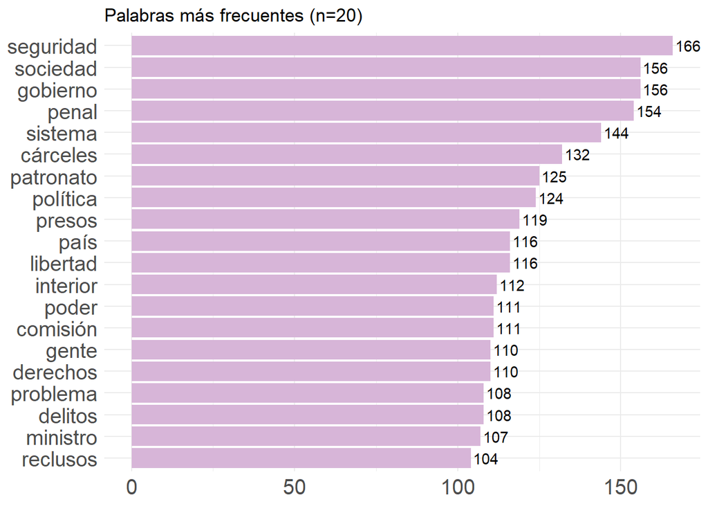

```r
##Grafico palabras más frecuentes

#creo un objeto con la 20 principales palabras
top = data.frame(topfeatures(dfm_intervenciones_depuradas,20))

#las defino como rownames
top$palabra = rownames(top)
View(top)

#hago el gráfico con ggplot
topplot = top[1:20, ] %>%
  ggplot(aes(x = reorder(palabra, topfeatures.dfm_intervenciones_depuradas..20.),
             y = topfeatures.dfm_intervenciones_depuradas..20., fill = palabra)) +
  geom_col(show.legend = FALSE) +
  coord_flip() +
  geom_text(aes(hjust = -0.1, label = topfeatures.dfm_intervenciones_depuradas..20.)) +
  theme_minimal() +
  theme(axis.title.y = element_blank(), axis.title.x = element_blank(), axis.text = element_text(size = 15)) +
  ggtitle("Palabras más frecuentes (n=20)") +
  scale_fill_manual(values = c(rep("#D7B5D8",20)))

plot(topplot)
```

A continuación realizo dos nubes de palabras, una general sin desagregar y otra según partido político. En concordancia con el gráfico anterior, las palabras que más resaltan en las intervenciones sin desagregar son gobierno, sociedad, seguridad y penal. Si lo vemos según el partido político del interviniente es posible destacar que el Frente Amplio menciona en mayor medida las palabras sociedad, política, seguridad y penal.

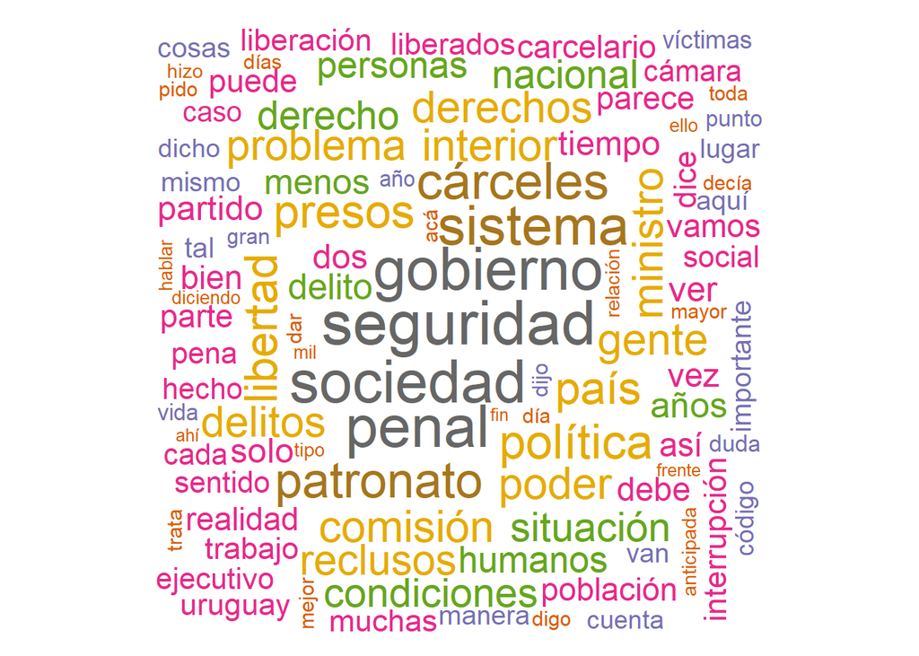

```r
##Nubes de palabras sin desagregación
quanteda.textplots::textplot_wordcloud(dfm_intervenciones_depuradas, min.count = 2,max_words = 200,
                                       random.order = FALSE,colors = RColorBrewer::brewer.pal(8,"Dark2"),comparison = F)
```

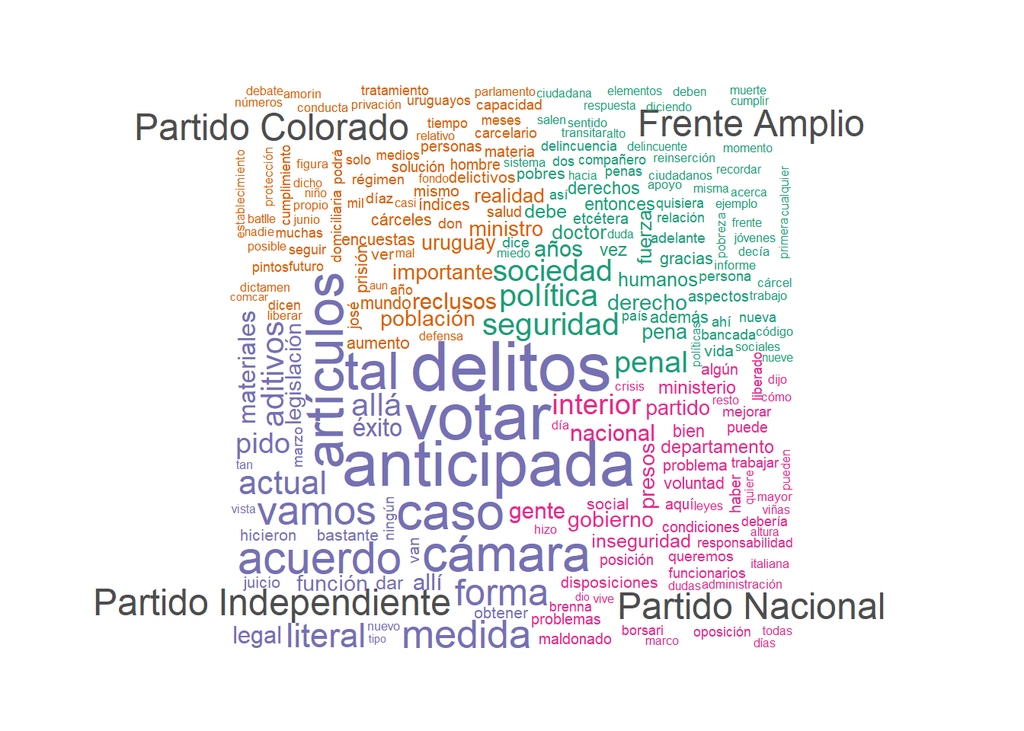

```r
##Nubes de palabras por grupos

quanteda.textplots::textplot_wordcloud(dfm_intervenciones_depuradas, min.count = 2,max_words = 500,
                                       random.order = FALSE,colors = RColorBrewer::brewer.pal(8,"Dark2"),comparison = T)
```

Seguridad es la palabra más mencionada en esta sesión, por lo que busco su correlación con otras palabras en el documento. Las dos palabras que correlacionan más son vida y reinserción.

```r
quanteda.textstats::textstat_simil(dfm_intervenciones_depuradas,selection = "seguridad",
                                   method = "correlation",margin = "features")%>%
  as.data.frame()%>%
  dplyr::arrange(-correlation)%>%
  dplyr::top_n(15)
```

| feature1 | feature2 | correlation |
| --- | --- | --- |
| vida | seguridad | 0.9999213 |
| reinserción | seguridad | 0.9994028 |
| término | seguridad | 0.9988453 |
| creación | seguridad | 0.9984308 |
| julio | seguridad | 0.9982922 |
| rectifique | seguridad | 0.9977724 |
| aparece | seguridad | 0.9977724 |
| sociales | seguridad | 0.9977724 |
| mientras | seguridad | 0.9977724 |
| sepa | seguridad | 0.9977724 |

[output cut: 6 more lines]

Realizo una búsqueda del contexto para conocer las cinco palabras previas y posteriores que aparecen en las intervenciones donde se hace referencia a la palabra más mencionada: seguridad.

```r
kwic_SEG = quanteda::kwic(quanteda::tokens(sesion_leyHSC$speech,
                                          remove_punct = TRUE,
                                          remove_numbers = TRUE),
                         pattern = quanteda::phrase(c("seguridad")),
                         window = 5)

library (DT)
datatable(kwic_SEG)
```

|  | docname | from | to | pre | keyword | post | pattern |
| --- | --- | --- | --- | --- | --- | --- | --- |
| 1 | text2 | 715 | 715 | agravamos las condiciones de la | seguridad | pública y no logramos el | seguridad |
| 2 | text2 | 1221 | 1221 | se le ofrezcan condiciones de | seguridad | pública suficientes Creo que es | seguridad |
| 3 | text2 | 1461 | 1461 | tiene que ver con la | seguridad | pero que no es el | seguridad |
| 4 | text2 | 1944 | 1944 | duda el mantenimiento de la | seguridad | pública Muchas gracias | seguridad |
| 5 | text4 | 715 | 715 | agravamos las condiciones de la | seguridad | pública y no logramos el | seguridad |
| 6 | text4 | 1221 | 1221 | se le ofrezcan condiciones de | seguridad | pública suficientes Creo que es | seguridad |
| 7 | text4 | 1461 | 1461 | tiene que ver con la | seguridad | pero que no es el | seguridad |
| 8 | text4 | 1944 | 1944 | duda el mantenimiento de la | seguridad | pública Muchas gracias | seguridad |
| 9 | text22 | 115 | 115 | penitenciarios pero también con la | seguridad | interna de una sociedad en | seguridad |
| 10 | text22 | 174 | 174 | ver Por supuesto entre la | seguridad | y el cumplimiento de los | seguridad |

[output cut: 157 more lines]

Realizo una red de co-ocurrencia entre términos. En concordancia con la asociación de palabras, en la red puede observarse la vinculación entre los términos seguridad, sociedad y gobierno.

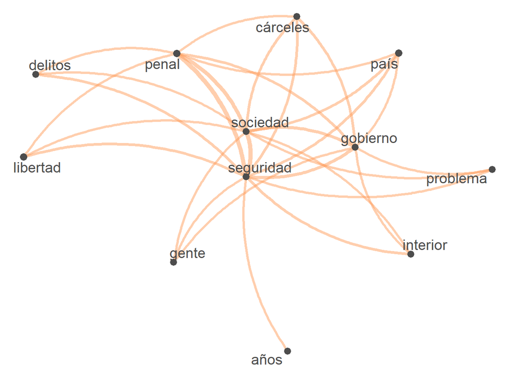

```r
base_fcm= dfm_intervenciones_depuradas%>%
  fcm(context = "document")

feat <- names(topfeatures(base_fcm, 25))
base_fcm_select <- fcm_select(base_fcm, pattern = feat, selection = "keep")
size <- log(colSums(dfm_select(base_fcm, feat, selection = "keep")))

set.seed(144)
quanteda.textplots::textplot_network(base_fcm_select, min_freq = 0.9, vertex_size = size / max(size) * 3,
                                     edge_color="#ff9d5c")
```

Por último, utilizo el diccionario LWIC-Spanish para identificar las emociones en las intervenciones según partido político y grafico el resultado. Con este análisis puede observarse que en todos los partidos políticos son más frecuentes las emociones positivas, aunque en las intervenciones del Partido Independiente la relación es más pareja.

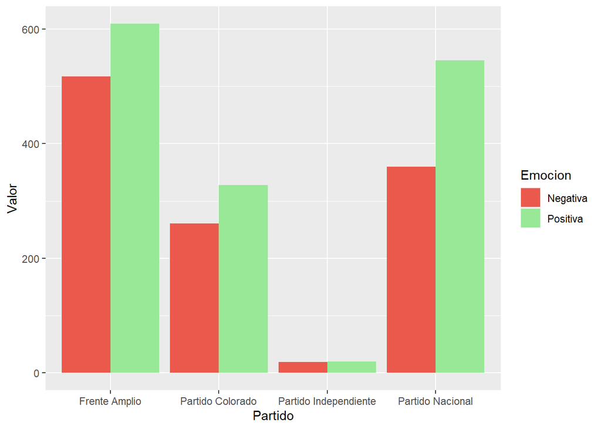

```r
lwic <- readRDS("C:/Users/Lucia/Documents/RCuali/EmoPosNeg_SPA.rds")
sent_dfm <- dfm_lookup(dfm_intervenciones, dictionary = lwic)
sent_int=convert(sent_dfm, to = "data.frame")

Partido <- c("Frente Amplio", "Partido Colorado", "Partido Independiente", "Partido Nacional")
Emocion <- c(rep("Negativa", 4), rep("Positiva", 4))
Valor <- c(517, 261, 19, 360, 609, 328, 20, 545)

tab_sent_int <- data.frame (Partido=Partido, Emocion=Emocion, Valor=Valor)

library(ggplot2)

ggplot(tab_sent_int, aes(x=Partido, y=Valor, fill=Emocion))+
  geom_bar(position="dodge", stat="identity")+
  scale_fill_manual(values = c("#EB594D", "#98E898"))
```